# Einzugsgebiete Abflussbeiwert

Daniel Abanto & Noah Reck

## Packages, die wir verwenden werde

```
##           gt      reshape        tidyr       lfstat      lattice         lmom
## "0.9.0.9000"      "0.8.9"      "1.3.0"     "0.9.12"    "0.20-45"        "3.0"
##          xts          zoo      formatR        readr  hydroEvents      ggplot2
##     "0.13.0"     "1.8-12"       "1.14"      "2.1.4"       "0.11"      "3.4.2"
##    lubridate   rmdformats        knitr        dplyr
##      "1.9.2"      "1.0.4"       "1.45"      "1.1.2"
```

## Einführung

Abfluss-Ereignis-Koeffizient: volumetrischer, ereignisspezifischer Quotient aus Abfluss und Niederschlagssumme. Er ist sowohl von den Eigenschaften des Einzugsgebiets abhängig z.B. Anteil und Durchlässigkeit befestigter Flächen, Bodeneigenschaften, Bewuchs, Geländeneigung, Vorfeuchte, Eisbedeckung, als auch von der Intensität und Dauer des Niederschlagsereignisses. Die Wirkung der Gebietseigenschaften kann sich mit Niederschlagsintensität und -dauer ändern. Er wird daher verwendet um die gekoppelten Abflussbildungsprozesse zu charakterisieren.

$$\Large \Psi = \frac{Q}{N}$$

## Berechnung des Abfluss-Ereignis-Koeffizient anhand Beispieldaten

Daten: Abflussdaten der Kinzig (m3/s) am Pegel Schenkenzell (Nr.3326) und Niederschlagsdaten (mm) aus Schiltach (Nr.7234) Zeitraum: 01.11.2010 bis 01.11.2023

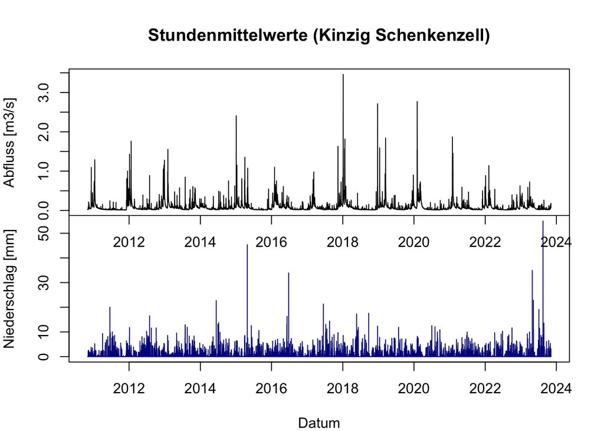

```r
# Niederschlag .txt
nis <- read.table("/Users/dabanto/Downloads/N_07234.txt", skip = 2,
    header = T)

# Abfluss .csv
abfluss <- read_csv("/Users/dabanto/Downloads/landespegel.csv")

# Datum formatieren
abfluss <- abfluss %>%
    mutate(date = as.POSIXct(`Datum / Uhrzeit`, format = "%d/%m/%Y %H:%M"))

nis <- nis %>%
    mutate(date = make_datetime(Jahr, Monat, Tag, Stunde))




# Merge, um beide Datensätze zu vereinien
workdat <- merge(abfluss, nis, by = "date")

# Ablusswerte müssen als Zahl gespeichert werden
workdat$Wert <- gsub(",", ".", workdat$Wert)

workdat$Wert <- as.numeric(workdat$Wert)

workdat <- tibble::rowid_to_column(workdat, "ID")

workdat <- workdat %>%
    select(ID, date, Stationsname, Parameter, Wert, N)

# umrechnung (hinterste zahl: ezg-größe in m2)
workdat$Wert <- workdat$Wert * 1000 * 3600/62805000

# plot niederschlag und abfluss
par(mfrow = c(2, 1), mar = c(0, 4, 4, 2))
plot(workdat$date, workdat$Wert, type = "l", ylab = "Abfluss [m3/s]",
    xlab = "Datum", main = "Stundenmittelwerte (Kinzig Schenkenzell)")
par(mar = c(4, 4, 0, 2))
plot(workdat$date, workdat$N, type = "l", col = "darkblue", ylab = "Niederschlag [mm]",
    xlab = "Datum")
```

## Identifikation einzelner Regenereignisse

eventPOT() mit Parametern threshold (Mindestwert von N um als Event identifiziert zu werden) und min.diff (Abstand, der erforderlich ist, damit zwei Ereignisse als getrennt betrachtet werden können) Der Output ist ein DataFrame mit den höchsten Niederschlagswerten.

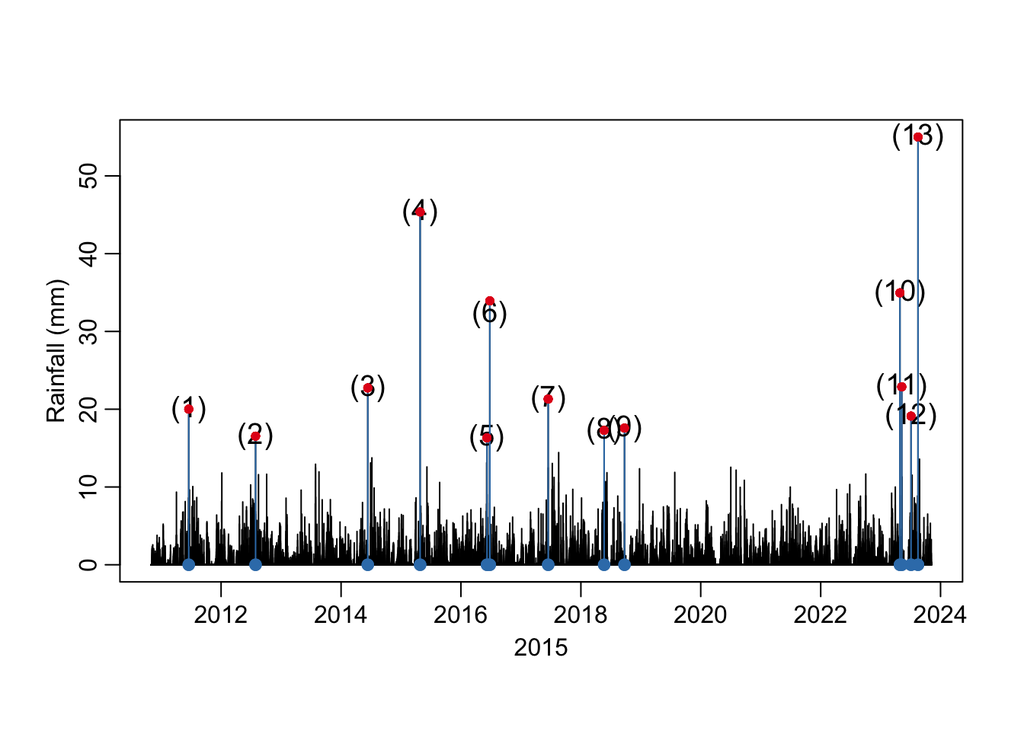

```r
# nach events suchen
events.P = eventPOT(workdat$N, threshold = 15, min.diff = 1)

# plot events
plotEvents(workdat$N, dates = workdat$date, events = events.P,
    type = "hyet", colline = "#377EB8", colpnt = "#E41A1C", ylab = "Rainfall (mm)",
    xlab = 2015, main = "")
```

## Events extrahieren

Funktion um Eventbasiert anhand einer Event ID Niederschlags und Abflussdaten zu extrahieren und in einem neuen Datensatz zu speichern. Nimmt Punkt höchsten Niederschlags und extrahiert gewünschte Länge an Datenpunkten vor und nach maximalem Niederschlag. Schwierigkeit: Eventspezifisches extrahieren ist schwierig mit generellem Code

```r
# rows extrahieren

events <- dplyr::pull(events.P, which.max)

# rows um Event extrahieren
rowRanges <- lapply(which(rownames(workdat) %in% events), function(x) x +
    c(-15:15))

# apply function
filt <- lapply(rowRanges, function(x) workdat[x, ])

# bind extracted rows as dataframe
out <- do.call(rbind, filt)

# Erstellen eines Datensatzes, mit Eventspezifischen
# Niederschlags- uns Abflussdaten

new <- do.call(rbind, Map(cbind, Name = seq_along(filt), filt))

head(new, 5) %>%
    gt()
```

| Name | ID | date | Stationsname | Parameter | Wert | N |
| --- | --- | --- | --- | --- | --- | --- |
| 1 | 5479 | 2011-06-17 08:00:00 | Schenkenzell Kinzig | Q | 0.02178171 | 0 |
| 1 | 5480 | 2011-06-17 09:00:00 | Schenkenzell Kinzig | Q | 0.02178171 | 0 |
| 1 | 5481 | 2011-06-17 10:00:00 | Schenkenzell Kinzig | Q | 0.01925961 | 0 |
| 1 | 5482 | 2011-06-17 11:00:00 | Schenkenzell Kinzig | Q | 0.01925961 | 0 |
| 1 | 5483 | 2011-06-17 12:00:00 | Schenkenzell Kinzig | Q | 0.01925961 | 0 |

## Abflussbeiwert mit Direktabfluss

```r
result_data <- data.frame() #erstellen eines leeren DataFrames


for (i in 1:length(events)) {  #Eine Iteration je Event
  #i <- 1
  new_test <- new %>%      #Alle Daten eines Events extrahieren
    filter(Name == i) %>%
    select(date, Wert, N)
  event <- xts(x = new_test, order.by = new_test$date)   #Event in Zeitreihe umwandeln
  event$date <- NULL                             #Datum löschen, da Matrix num() oder chr() braucht
  event$baseflow <- baseflow(event$Wert)    #Baseflow für Event i berechnen
  df = data.frame(date=index(event), coredata(event), event_id = rep(i)) #Dataframe mit Baseflow Daten füllen
  result_data <- bind_rows(result_data, df)

}

result_data <- result_data %>%  #na's filtern
  drop_na()


agg <- result_data %>% #events aggregieren
  group_by(event_id) %>%
  summarise(across(c(Wert, N, baseflow), sum))

agg <- agg %>%  #spalten umbenennen
  dplyr::rename(Qges = Wert) %>%
  dplyr::rename(Qb = baseflow)

agg$Qf <- (agg$Qges-agg$Qb) #quickflow berechnen

agg$RFC <- agg$Qf/agg$N #abflussbeiwert berechnen

head(agg) %>%
  gt()
```

| event_id | Qges | N | Qb | Qf | RFC |
| --- | --- | --- | --- | --- | --- |
| 1 | 1.4671698 | 31.30 | 0.5841197 | 0.88305010 | 0.028212463 |
| 2 | 7.3423262 | 45.33 | 2.8850154 | 4.45731080 | 0.098330262 |
| 3 | 0.5433963 | 27.04 | 0.4619810 | 0.08141526 | 0.003010919 |
| 4 | 3.6813375 | 54.13 | 2.0555952 | 1.62574227 | 0.030034034 |
| 5 | 2.7620350 | 26.55 | 2.1053454 | 0.65668960 | 0.024734072 |
| 6 | 3.7514401 | 66.76 | 2.2433648 | 1.50807536 | 0.022589505 |

## Abflussbeiwerte mit Gesamtabfluss des Events

Nachdem das Ergebnis des Direktabflusskoeffizienten unplausibel erschien haben wir den Abflussbeiwert für den Gesamtabfluss des Events berechnet. Der zuvor aggregierte Datensatz wurde verwendet um mithilfe von limbs() den Start und das Ende des Abflussereignisses genauer zu bestimmen.

```r
for (i in 1:nrow(agg)) { #Eine Iteration je Event
  new_t <- new %>%      #Event filtern
    filter(Name == i) %>%
    select(Wert, N) %>%
    mutate(id = row_number())

  #nachdem der Event gefiltert wurde, ermitteln wir den Event Baseflow
  BFI_res <- tryCatch(eventBaseflow(new_t$Wert), error = function(e) return(NA))
  print(rep(i)) #und dann, wann die Steigung des Events beginnt und aufhört.
  ifelse(!is.na(BFI_res), df <- limbs(data = new_test$Wert, dates = NULL, events = BFI_res), NA)

  #aus den erzeugten DataFrame extrahieren wir spezifische Werte
  agg$Q_event[i] <- ifelse(is.na(df), NA, df[1, "sum"])
  agg$srt_event[i] <- ifelse(is.na(df), NA, df[1, "srt"])
  agg$end_event[i] <- ifelse(is.na(df), NA, df[1, "end"])

  #Niederschlagssumme wird für jedes Event neu berechnet.
  agg$sum_n[i] <- new %>%
    filter(Name == i) %>%
    slice(agg$srt_event[i]:agg$end_event[i]) %>%
    summarise(sum_value = sum(N)) %>%
    pull(sum_value)

}
```

```r
agg$RFC_2 <- agg$Q_event/agg$sum_n #neuer Abflussbeiwert wird berechnet
```

[figure not shown]

[output not shown]

| event_id | Qges | N | Qb | Qf | RFC | Q_event | srt_event | end_event | sum_n | RFC_2 |
| --- | --- | --- | --- | --- | --- | --- | --- | --- | --- | --- |
| 1 | 1.4671698 | 31.30 | 0.5841197 | 0.88305010 | 0.028212463 | 1.1049057 | 14 | 23 | 29.01 | 0.03808706 |
| 2 | 7.3423262 | 45.33 | 2.8850154 | 4.45731080 | 0.098330262 | 5.8378983 | 9 | 24 | 45.33 | 0.12878664 |
| 3 | 0.5433963 | 27.04 | 0.4619810 | 0.08141526 | 0.003010919 | 5.8378983 | 9 | 24 | 27.04 | 0.21589860 |
| 4 | 3.6813375 | 54.13 | 2.0555952 | 1.62574227 | 0.030034034 | 2.7290184 | 14 | 23 | 53.29 | 0.05121070 |
| 5 | 2.7620350 | 26.55 | 2.1053454 | 0.65668960 | 0.024734072 | 0.8605493 | 17 | 19 | 9.03 | 0.09529893 |
| 6 | 3.7514401 | 66.76 | 2.2433648 | 1.50807536 | 0.022589505 | 2.3488703 | 15 | 24 | 66.76 | 0.03518380 |
| 7 | 0.9122522 | 34.07 | 0.6020862 | 0.31016606 | 0.009103788 | 0.4370098 | 14 | 21 | 34.07 | 0.01282682 |
| 8 | 0.7629329 | 26.63 | 0.6924290 | 0.07050390 | 0.002647537 | 0.4370098 | 14 | 21 | 26.63 | 0.01641043 |
| 9 | 1.3407786 | 25.85 | 0.5358299 | 0.80494867 | 0.031139214 | 1.0405923 | 15 | 24 | 25.85 | 0.04025502 |
| 10 | 3.4770480 | 46.55 | 2.3756962 | 1.10135180 | 0.023659545 | 1.7251684 | 15 | 21 | 46.55 | 0.03706055 |

## Vergleich der Abflussbeiwerte

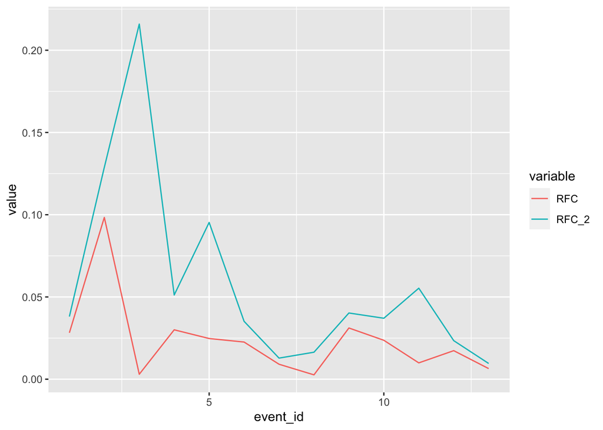

```r
plot_q <- agg %>%
    select(event_id, RFC, RFC_2)

plot_q <- as.data.frame(plot_q)

plot_q <- melt(plot_q, id = c("event_id"))

p1 <- plot_q %>%
    group_by(variable) %>%
    ggplot(aes(x = event_id, y = value, group = variable, color = variable)) +
    geom_line()

p1
```